# EXCESS MORTALITY OF COVID_19, IRAN

Yasamin Vaziri

2023-05-03

## Summery to what I’ve done

to begin, as we discussed in class, a possible way (which I’ve done) to answer the first question, for the past 5 years, for each province and month, we fit a linear model, then we predicted the years after covid base on our model.

the number that we have predicted is ‘num_predict’, we go through ’2*sigma+ num_predict’ and we conclude base on this number. if this is greater that the number in data set, it means that it is in the 95% interval which means we did not have excess mortality but if don’t, this means there exists excess mortality. getting the difference between the n we predicted and the n in the data set, we reach excess mortality number!.

for the heat map, it is better to be normalized, we can divide the excess mortality to all ‘n’ of that province. Because, the more crowded province has more deaths so the heat map will not be trustworthy except we normalized the data so the severity of corona will be increased in that province so that we can trust.

we can answer the second and third question, base on the question one.

And finally, for the last question, we draw a map base the normalized excess mortality to compare different provinces where the less normalized excess mortality can show better result.

but to be more precise, we don’t care if the older people die, because the youth can struggle with the virus but the older people might die sooner. so the number of deaths in youth is a sign that corona was more severe.

## Question 1

first we saw the connection of the first and second half of the years with total mortality:

```r
library(data.table)
```

```r
library(ggplot2)
```

we read file from:

```r
d = fread('C:\\Users\\Yasmine\\Documents\\daaa\\iranprovs_mortality_monthly (1).csv', encoding = "UTF-8")
```

and we use another variable in data set as well as deleting two columns sex and age

```r
d$ym_num = d$y + d$m / 12 - 1/24
ds = d[, .(n = sum(n)), .(y, m, ym_num)]
```

and now this is the plot showing us that there is a connection!

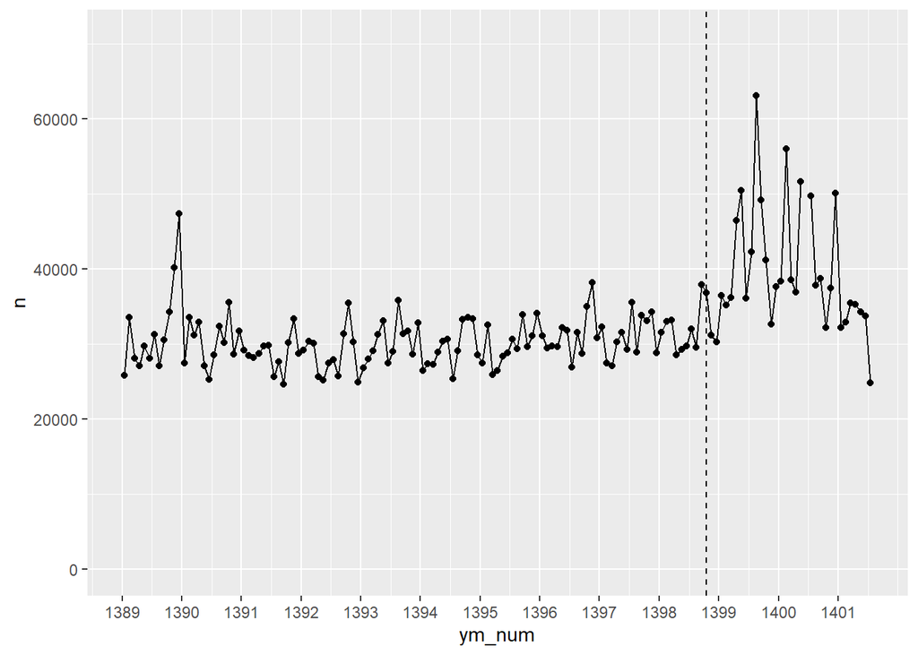

also clear that when did corona start: Oct-Nov (Dey) 1398.

now, before starting fitting, we creat the new data set

```r
ds = d[, .(n = sum(n)), .(y, m, ym_num, prov)]
```

and to avoid non linear parameters, we only look at the past 5 years. meanwhile we define the time that covid had started:

```r
ds = d[, .(n = sum(n)), .(y, m, ym_num, prov)]


ym_num_covid = 1398 + 10/12 - 1/24


ym_num_start = ym_num_covid - 5
```

after adding 3 columns for answers,

```r
ds$excess_mortality=0
ds$norm_excess_mortality=0
ds$num_predict=0
```

we fit the model:

```r
for (i in 1:31) {
  PROV = unique(ds$prov)[i]
  for (j in 1:12) {
    M = j
    dsm = ds[prov == PROV & m == M,]
    dsm = dsm[ym_num > ym_num_start]
    dsm2fit = dsm[ym_num < ym_num_covid]
    fit = lm(n ~ ym_num, dsm2fit)
    pvalue = summary(fit)$coefficients[,4][2]
    if(pvalue > .7){
      dsm$num_predict = mean(dsm2fit$n)
    } else{
      dsm$num_predict = predict(fit,dsm)
    }
    sigman = summary(fit)$sigma
    dsm$excess_mortality = dsm$n-dsm$num_predict



    dsm[dsm$num_predict + 2*sigman > dsm$n]$excess_mortality = 0
    ds[prov == PROV & m == M & ym_num > ym_num_start]$excess_mortality = dsm$excess_mortality
    ds[prov == PROV & m == M & ym_num > ym_num_start]$norm_excess_mortality = dsm$excess_mortality/sum(dsm$n)
    #random province
    if(j == 12){

     ggplot(dsm)+
        geom_smooth(aes(ym_num, num_predict), method = 'lm')+
        geom_point(aes(ym_num, n), size = 1)+
        scale_x_continuous(breaks = 1389:1401)+
         geom_vline(xintercept = 1398 + 10/12 -1/24, linetype = 'dashed')+
         ggtitle(label = PROV, subtitle = paste('month: ', M))+xlab("year")+xlab("death")

    }


  }

}
```

drawing the heat map :

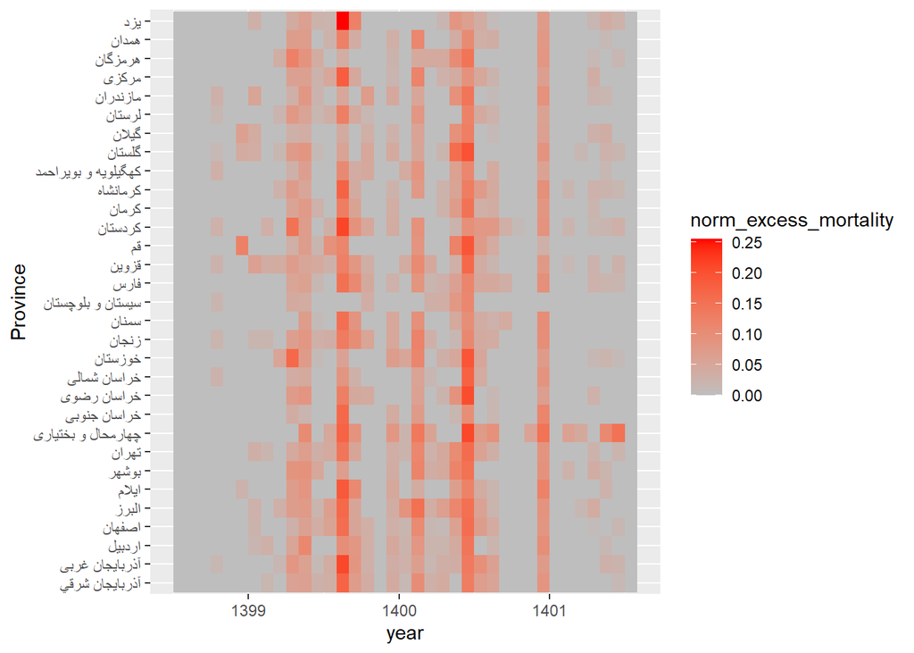

So the first question is answered!

as an example, the plot of a random province is also shown below:

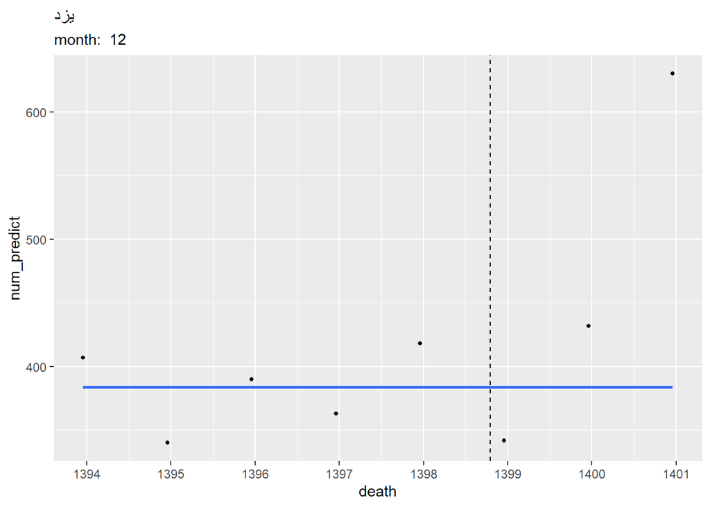

the plots of all months can be shown base on the code.

## Question two

this is simple to calculate, we get sum from all excess mortality:

```r
print("total excess mortality: ")
```

```
## [1] "total excess mortality: "
```

```r
print(sum(ds$excess_mortality))
```

```
## [1] 271555
```

## Question three

```r
for (i in 1:31) {
  PROV=unique(ds$prov)[i]
  print(paste("total excess mortality in ", PROV, " :", sum(ds[ds$prov == PROV, ]$excess_mortality)))

}
```

```
## [1] "total excess mortality in  آذربايجان شرقي  : 17087.35"
## [1] "total excess mortality in  آذربايجان غربی  : 12957.5000000001"
## [1] "total excess mortality in  اردبیل  : 4624.70000000002"
## [1] "total excess mortality in  اصفهان  : 18549.9499999999"
## [1] "total excess mortality in  البرز  : 10924.4"
## [1] "total excess mortality in  ایلام  : 1725.7"
## [1] "total excess mortality in  بوشهر  : 3092.30000000001"
## [1] "total excess mortality in  تهران  : 49977.4999999998"
## [1] "total excess mortality in  چهارمحال و بختیاری  : 5484.59999999999"
## [1] "total excess mortality in  خراسان جنوبی  : 1566.6"
## [1] "total excess mortality in  خراسان رضوی  : 19570.3"
## [1] "total excess mortality in  خراسان شمالی  : 1994.80000000001"
## [1] "total excess mortality in  خوزستان  : 15848.9"
## [1] "total excess mortality in  زنجان  : 3940.30000000001"
## [1] "total excess mortality in  سمنان  : 1999.49999999999"
```

[output cut: 16 more lines]

## Question four

as I said, we can use the normalized excess mortality. but note that this result will be without the intervention of age. In this way, we eliminate the influence of the population and we only look at the number of deaths.

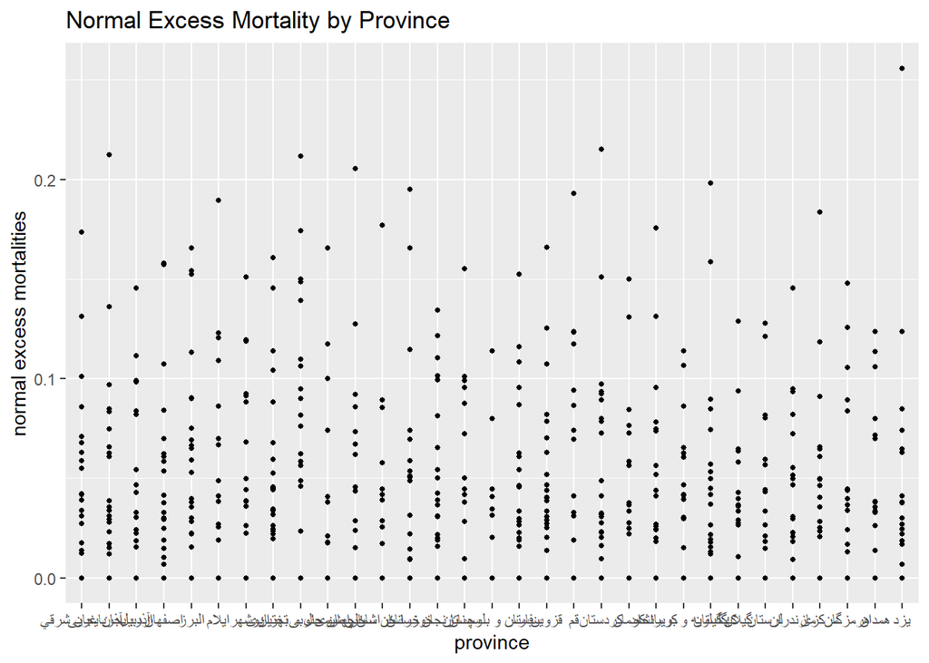

so base on the plot, I would answer a province like “Sistan & Balouchestan”. Generally, there are several ways to answer this question, we could also use corona waves in the way that what provinces were more successful in different waves.

If we want to influence age, we can assign a weight to each age group so that the young age group bears more weight, then we add the number of deaths in each age group according to their weight, and each province that A lower total dose means that it has been more successful, which is statistically consistent with the first method.